# Ford GoBike System Data

## by Abdelrhman Hamdy

## Investigation Overview

> Through this presentaion we will try to answer 2 Questions :  
> 1- who uses Bike Share service more ?  
> 2- who uses Bike Share service longer ?

## Dataset Overview

> The dataset "Ford GoBike System Data" consists of 900,000 rows and 15 columns. Columns include features like : gender, age , user type, trip start time , trip end time, bike ID

## Users ages vs the number of times the service is used

> Over the past decade, bike-share has been one of the great U.S transportation success stories. Many people ,especially young ones, used it as a main transportation method for going and returning from workplace. The following visualisation shows service use frequency during Feb 2019 associated with every age range

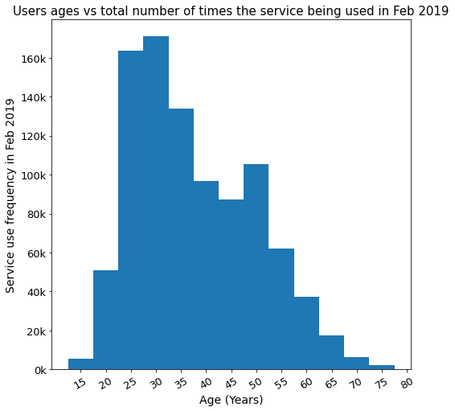

```python
# specify the bins of the histogram to have 5 years in each bin
bins=np.arange(15 ,80 + 5 , 5) # the yougest user in the dataset is 15 years, and tha oldest user is 80 years
bins_y=np.arange(0,180000,20000)
bins_y_label = ['{:0.0f}'.format(v) + "k" for v in bins_y/1000]

plt.figure(figsize=[8,8])

plt.hist(df['age'],bins=bins)

plt.xticks(bins+2.5,bins,rotation=30,fontsize=13); # i added 2.5 to move x values to be in the center of each bar

plt.yticks(bins_y,bins_y_label,fontsize=13)

plt.title('Users ages vs total number of times the service being used in Feb 2019',fontsize=15);

plt.xlabel('Age (Years)',fontsize=14);

plt.ylabel('Service use frequency in Feb 2019',fontsize=14);
```

## Does age effect ?

> Younger people tend to depend more on bike-share service, so they tend to be subscribers more than customers, in contrast older ones tend to use it when they need it, which make them customers.

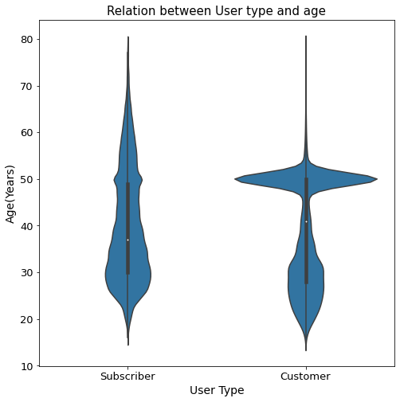

```python
color=sb.color_palette()[0] # define the color of the plot
plt.figure(figsize=(8,8))
sb.violinplot(data=df,x='usertype',y='age',color=color)
plt.xlabel('User Type',fontsize=14);
plt.ylabel('Age(Years)',fontsize=14);
plt.title('Relation between User type and age',fontsize=15);
plt.xticks(fontsize=13);
plt.yticks(fontsize=13);
```

## Do men use Bike-share more than women ?

> socially, bikes are more popular among men than women, and that's obvious in the data with about 77% percentage of men against 23% of women. This seems a very large difference !

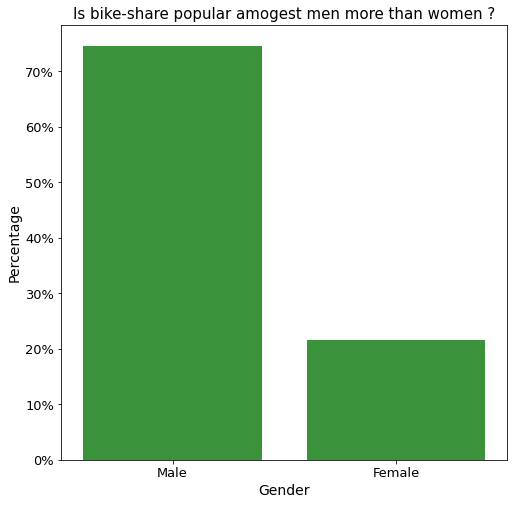

```python
#specifing the values of y axis to be percentage
bins=np.arange(0, .80, .10)

bins_label = ['{:0.0f}'.format(v) + "%" for v in bins*100] # create the labels to change -for example- 0.1 to 10%

dfm=df.query('gender != 0') # there are some entries with unknown gender, so i exculded these entries here

order=dfm.gender.value_counts().index # creating variable to order the bar graph from highest to lowest

plt.figure(figsize=(8,8))

sb.countplot(data=dfm,x='gender',order=order,color=sb.color_palette()[2])

plt.xticks([0,1],['Male','Female'],fontsize=13) # the gender encoded in the dataset 1 for male, 2 for women, so i modified that here

plt.yticks(bins*df.shape[0],labels=bins_label,fontsize=13); # changing y values from number of times the service used with each gender
                                                # to be percentage
plt.ylabel('Percentage',fontsize=14);

plt.xlabel('Gender',fontsize=14)

plt.title('Is bike-share popular amogest men more than women ?',fontsize=15);
```

## Variation in the service usage during the day , and week

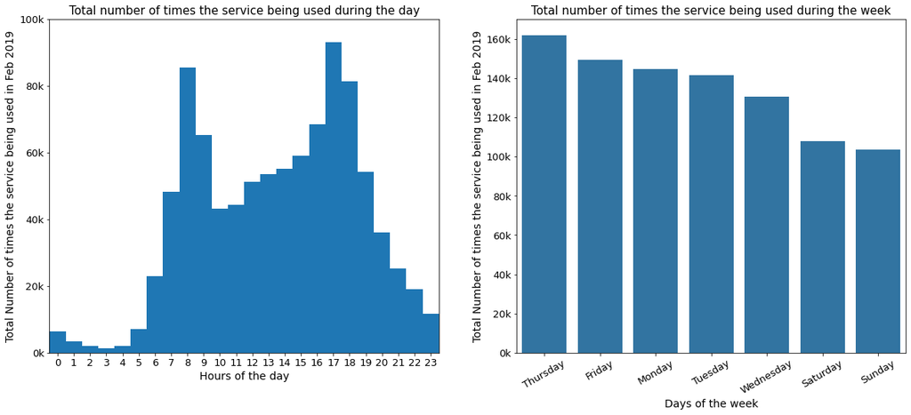

```python
# define the bins here to represent the hours of day
bins=np.arange(0,25,1)

#creating of y labels -to be for example 20k rather 20000-
bins_y_1=np.arange(0,120000,20000)
bins_y_label_1 = ['{:0.0f}'.format(v) + "k" for v in bins_y/1000]


plt.figure(figsize=[20,8])


plt.subplot(1,2,1)
plt.hist(df['hour'],bins=bins)

plt.xticks(bins+0.5,bins,fontsize=13);# changing the x values location to be centered at each bar
plt.xlim((0,24))
plt.yticks(bins_y_1,bins_y_label_1,fontsize=13)

plt.xlabel('Hours of the day',fontsize=14);
plt.ylabel('Total Number of times the service being used in Feb 2019',fontsize=14);
plt.title('Total number of times the service being used during the day',fontsize=15);



plt.subplot(1,2,2)
order = df.day.value_counts().index # creating variable to order the bar graph from highest bar to lowest

#creating of y labels - to be for example 20k rather 20000 -
bins_y_2=np.arange(0,180000,20000)
bins_y_label_2 = ['{:0.0f}'.format(v) + "k" for v in bins_y_2/1000]


sb.countplot(data=df,x='day',order=order,color=sb.color_palette()[0]);

plt.xticks(rotation=30,fontsize=13);
plt.yticks(bins_y_2,bins_y_label_2,fontsize=13)
plt.xlabel('Days of the week',fontsize=14);
plt.ylabel('Total Number of times the service being used in Feb 2019',fontsize=14);
plt.title('Total number of times the service being used during the week',fontsize=15);
```

## User type percentages

Do people really love using bike-share or they just use it when they need it ? The graph shows that about 95% of users are subscribers !

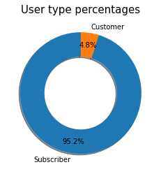

```python
plt.pie(df.usertype.value_counts(),labels=df.usertype.value_counts().index,
        startangle=90,wedgeprops = {'width' : 0.4}, shadow=True,
autopct='%1.1f%%', pctdistance = 0.8,);

plt.title('User type percentages',fontsize=15);
```

# The average trip duration for subscribers vs customers

Although the ratio of customers is very low compared to subscribers, but when they use the service they tend to use it longer than subscribers with considerable margin, which is a good sign of understading the importance of this service. With some effort these customers can be converted to subscribers !

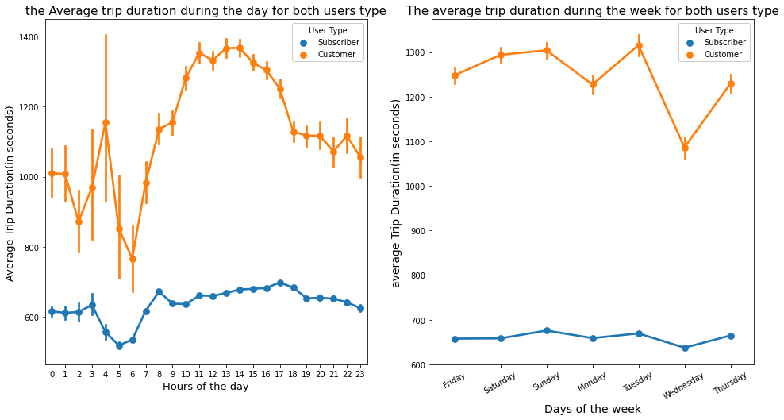

```python
plt.figure(figsize=[16,8])


plt.subplot(1,2,1)
ax = sb.pointplot(data = df, x = 'hour', y = 'tripduration', hue =  'usertype')
ax.legend(loc = 1, ncol = 1, framealpha = 1, title = 'User Type') # creating and adjust the location  of the legend
plt.title('the Average trip duration during the day for both users type',fontsize=15)
plt.xlabel('Hours of the day',fontsize=13)
plt.ylabel('Average Trip Duration(in seconds)',fontsize=13)

plt.subplot(1,2,2)
ax = sb.pointplot(data = df, x = 'day', y = 'tripduration', hue =  'usertype');
ax.legend(loc = 1 , ncol = 1, framealpha = 1, title = 'User Type');
plt.title('The average trip duration during the week for both users type',fontsize=15);
plt.xlabel('Days of the week',fontsize=14);
plt.ylabel('average Trip Duration(in seconds)',fontsize=14);
plt.xticks(rotation=30);
```